# Lecture 13：将来を考えた選択と動学的離散選択モデル

計量経済学II

作者

Kei Ikegami

**重要この講義で押さえたいこと**

- 将来の購買を予測することと、消費者自身が将来を考えて選ぶことを区別する。現在の行動が将来の状態を変えるとき、将来価値を含めて選択を考える必要がある。
- 状態・行動・状態遷移を定め、Bellman方程式で意思決定を表す。バスのエンジン交換を例に、モデルから選択確率とデータを作る。
- 第2回と同じType I極値ショックを使うと、将来価値を含む選択でもlogitの式が得られる。
- NFXPとCCPという2つの方法で維持費・交換費を推定し、真値と比較する。
- 交換費への補助を反実仮想として計算し、将来価値を無視したモデルでは予測がどう変わるかを確かめる。

## 前回とのつながり・今回のゴール

第4回では、個人の好みの違いを集計した需要から、合併や費用変化の影響を計算した。第6〜9回では同じ異質性を、購買履歴やコンジョイントの回答から「この人は何を好みそうか」を学ぶために使った。第10回ではその推定結果をクーポンの配布に使い、第11回では個人の履歴から学ぶ同じ発想を、購買率と離脱確率へ広げた。第12回のゲスト講義を挟み、今回は意思決定の時間軸をもう少し詳しく考える。

まず、**分析者が将来を予測することと、消費者が将来を考えて行動することは、別の話である。** 第11回のBG/NBDでは、購買率や離脱確率の異質性を使って将来の購入回数を予測した。しかし、消費者が「来月の値下げを待とう」と考えて購入を遅らせる仕組みまでは入れていなかった。

例えば、同じスマートフォンを使い続けている人を考えよう。そのブランドが好きなのかもしれないし、まだ十分使えるのかもしれない。あるいは、次の新製品や値下げを待っているのかもしれない。購入履歴から好みを学ぶだけでは、この最後の理由は説明しきれない。今買うと、これからしばらく買い替えなくてよくなる。待つと、古い端末の不便を引き受ける代わりに、将来の選択肢を残せる。このように、現在の選択は将来の状態を変える。

そこで、今の効用に、行動した先で得られる将来の効用を加えて比較する。これが**動学的離散選択（dynamic discrete choice, DDC）**の考え方である。第2回の「効用の高い選択肢を選ぶ」という枠組みに、将来価値を加えることになる。

今回は、仕組みを理解しやすいバスのエンジン交換問題で、状態・行動・価値関数を一つずつ導入する。維持費と交換費をデータから推定し、「交換費に補助が出たら、交換のタイミングはどう変わるか」まで計算する。ここでは動学に集中するため、維持費と交換費のパラメータは共通とする。個人の好みの違いと、過去の行動が作る状態の違いをどう分けるかは、第14回で考える。

**ノート記法について：今日から $\beta$ は割引因子**

第2〜9回では $\beta$ は「属性への選好パラメータ」だった（効用 $u = x'\beta - \alpha p + \cdots$ の $\beta$）。しかし**動学の文献では $\beta$ は割引因子（discount factor）を指すのが標準**である。この第13〜15回では、この文献の慣習に従い、**$\beta$ を割引因子**として使う。効用（flow utility）のパラメータは $\theta$ と書く。混乱しないよう、初出のここで明示的に断っておく。$\beta$ は $0 < \beta < 1$ の割引因子で、今日の1単位の効用に対して1期後の効用を $\beta$ 倍に割り引く、あの $\beta$ だ。

## バスのエンジンをいつ交換するか

Rust (1987) が扱ったのは、米国マディソン市のバス公社で整備を担当していたHarold Zurcherのエンジン交換判断である。走行距離が長くなると、エンジンの維持費がかかる。一方、交換すれば維持費は下がるが、その時点で大きな交換費を払うことになる。

今日だけを考えるなら、今日の維持費と交換費を比べればよい。しかし、今交換すると明日以降の維持費も変わる。少し高い交換費を払っても、今後の費用が十分下がるなら交換した方がよい。この判断を、毎月の走行距離と交換記録から推定する。

Rustは、Zurcherが期待割引費用を最小化すると仮定し、観測された交換判断を説明する維持費・交換費のパラメータを推定した。一人の担当者による判断でも、多数のバスを長期間追えば、状態によって判断がどう変わるかを調べられる。

**ノート原論文のデータと、この講義のシミュレーション**

Rust の原標本はマディソン市バス公社の**162台、15,406 bus-month observations**である。ただし本講義で以降に出す交換費・維持費・状態数は、**説明用に設定したシミュレーション値**であって Rust の推定値ではない。ここでの狙いは、モデルの構造と推定の流れを手を動かして体感することにある。

## モデルの部品

Rust のバス問題を、我々のシミュレーション用に最小構成で組む。部品を一つずつ並べる。

まず1期間の順序を固定する。添字の取り違えを防ぐため、Bellman方程式を書く前にこの5段階へ戻ろう。

| 順序 | 時点 $t$ で起きること | 記号 |
| --- | --- | --- |
| 1 | 現在の走行距離を観測 | $x_t$ |
| 2 | 維持か交換を選ぶ | $a_t\in\{0,1\}$ |
| 3 | 当期効用と選択ショックを受け取る | $u(x_t,a_t)+\varepsilon_t(a_t)$ |
| 4 | 行動と距離増分により次期状態へ移る | $x_{t+1}\sim P(\cdot\mid x_t,a_t)$ |
| 5 | $t+1$で同じ問題を繰り返す | $\beta V(x_{t+1})$ |

**状態 $x$（走行距離）**。エンジンの累積走行距離を、離散グリッド $x \in \{0, 1, \ldots, K-1\}$ で表す。$x=0$ は新品同様、$x$ が大きいほど走り込んだ状態だ。今日は $K = 20$ 状態でいく（現実には走行距離をビンに区切って離散化する）。

**行動 $a$**。毎期、Zurcher は2択を迫られる：$a = 0$（**維持**＝そのまま使う）か $a = 1$（**交換**＝エンジンを載せ替える）か。

**flow utility $u(x, a; \theta)$**（その期に得る「効用」＝コストの符号を反転したもの）。線形で十分だ：

$$u(x, 0) = -\theta_1\, x, \qquad u(x, 1) = -RC.$$

- 維持（$a=0$）すると、走行距離 $x$ に比例した維持費がかかる。$\theta_1 > 0$ は「1状態あたりの維持費の増分」。走り込んだバスほど維持が高くつく。
- 交換（$a=1$）すると、載せ替え費用 $RC$（replacement cost）がかかる。これは走行距離によらず一定とする（新品エンジンの値段は今の距離と無関係）。

**状態遷移**。行動によって、次期の走行距離が確率的に決まる。

- 維持（$a=0$）：距離は進む。$x' = \min(x + j,\, K-1)$、$j \in \{0, 1, 2\}$ を確率 $(p_0, p_1, p_2)$ で引く（1ヶ月で0・1・2ビンぶん進む）。
- 交換（$a=1$）：距離はリセットされる。$x' = \min(0 + j,\, K-1)$、$j$ は同じ分布。**新品エンジンなので $x=0$ から再スタートし、そこから距離が進む。**

**T1EV ショック $\varepsilon_a$**。各行動 $a$ には、分析者に見えない効用ショック $\varepsilon_a$ が乗る。第2回と同じく、これを Type I 極値分布（Gumbel）と仮定する。これが今日の全ての「logit らしさ」の源になる。

**割引因子 $\beta$**。将来の効用を $\beta$ 倍に割り引く。ここでは $\beta = 0.95$ に固定する（後で「なぜ推定せず固定するのか」を議論する）。

## Bellman方程式とlogsum

さて、意思決定者はどう行動を選ぶのか。「今日のコストだけ」を見るのではなく、「今日のコスト＋将来のコストの割引期待値」を見る。これを表すのが**価値関数（value function）**だ。

まず、状態 $x$ で行動 $a$ を選んだときの価値を、**choice-specific value function** $v(x, a)$ で書く：

$$v(x, a) = u(x, a) + \beta \sum_{x'} P(x' \mid x, a)\, V(x').$$

第1項 $u(x,a)$ は今日の flow utility、第2項は「行動 $a$ の結果として遷移する次期状態 $x'$ での価値 $V(x')$ の割引期待値」だ。$P(x' \mid x, a)$ は上で定めた状態遷移確率。

では $V(x)$（状態 $x$ の価値、ショックを見る前の期待値）は何か。意思決定者は $\varepsilon_a$ を見てから、$v(x,a) + \varepsilon_a$ が最大になる $a$ を選ぶ。だから

$$V(x) = \mathbb{E}_{\varepsilon}\left[\max_{a \in \{0,1\}} \big(v(x, a) + \varepsilon_a\big)\right].$$

ここで、第2回で使った誤差分布が役立つ。$\varepsilon_a$ が Type I 極値分布なら、この「ショック込みの最大値の期待値（Emax）」は、**logsumの式**で書ける：

$$V(x) = \log\left(\sum_{a} \exp(v(x, a))\right) + \gamma
= \log\big(\exp(v(x,0)) + \exp(v(x,1))\big) + \gamma,$$

$\gamma \approx 0.5772$ は Euler 定数（Euler-Mascheroni 定数）だ。第4回の合併分析で消費者余剰を測ったあの inclusive value（logsum）と、まったく同じ数式である。

そして選択確率も、今回もまた **logit** になる：

$$P(a = 1 \mid x) = \frac{\exp(v(x, 1))}{\exp(v(x, 0)) + \exp(v(x, 1))}.$$

**重要将来価値を含めても、選択確率はlogitになる**

第2回で選択確率は $s_j = \exp(\delta_j) / \sum_k \exp(\delta_k)$ だった。$\delta_j$ は「財 $j$ の（今日の）平均効用」。

動学では、この $\delta_j$ が座っていた場所に、**将来価値まで織り込んだ choice-specific value $v(x,a) = u(x,a) + \beta \mathbb{E}[V(x')]$** が座る。ただそれだけで、選択確率は今回もまた logit の形をとる。$V$ を求めるのに Emax = logsum を使い、その $V$ が $v$ に入り、その $v$ で選択確率が決まる——**T1EV の親和性は、静学から動学へそのまま持ち越せる**。この性質により、価値関数を計算できれば、第2回と同じように選択確率から尤度を作れる。

**ノート導出：Emax が logsum になる（第2回の再掲）**

$\varepsilon_0, \varepsilon_1$ が独立に Gumbel（位置0・尺度1）に従うとする。$W_a := v(x,a)$ と略記すると、Emax は

$$\mathbb{E}\left[\max_a (W_a + \varepsilon_a)\right] = \log\left(\sum_a e^{W_a}\right) + \gamma.$$

証明のスケッチ：$\max_a(W_a + \varepsilon_a)$ 自体が、位置 $\log\sum_a e^{W_a}$・尺度1の Gumbel 分布に従う（独立 Gumbel の最大値は再び Gumbel、という max-stability）。Gumbel 分布の平均は「位置 $+\ \gamma$」なので、期待値は $\log\sum_a e^{W_a} + \gamma$ となる。選択確率が logit になるのも同じ max-stability の帰結で、第2回の導出をそのまま状態 $x$ ごとに適用すればよい。

Bellman 方程式は $V$ について**不動点（固定点）方程式**になっている：$V$ が右辺（$v$ を通じて）に現れ、左辺にも現れる。この $V$ を数値的に解くのが、次の「価値関数反復」だ。

## Rシミュ1：価値関数反復で DP を解く

Bellman 方程式を解く最も基本的な方法が、**価値関数反復（value function iteration, VFI）**だ。$V$ の初期値（例えば全部0）から始めて、Bellman 作用素を繰り返し適用する。適当な $V$ を右辺に入れて左辺の新しい $V$ を計算し、それをまた右辺に入れる……を、$V$ が動かなくなる（収束する）まで繰り返す。

まず状態遷移行列を作る。$P_0$（維持したときの遷移）と $P_1$（交換したときの遷移）は、いずれも $K \times K$ 行列で、行が現在状態 $x$、列が次期状態 $x'$ だ。

```r
# ---- モデルの基本設定 ----
K     <- 20            # 走行距離の状態数（0..19）
beta  <- 0.95          # 割引因子（固定）
theta1_true <- 0.15    # 維持費の傾き（1状態あたり）
RC_true     <- 8.0     # エンジン交換費
p_trans <- c(0.30, 0.55, 0.15)   # 1期に +0/+1/+2 状態進む確率
EULER   <- 0.5772156649015329    # Euler 定数（logsum の定数項）

xs <- 0:(K - 1)        # 状態の値そのもの（走行距離）

# 状態遷移行列を作る
# P0: 維持したとき（x から距離が進む）, P1: 交換したとき（0 にリセットして進む）
build_transition <- function(K, p) {
  nj <- length(p)
  P0 <- matrix(0, K, K)
  P1 <- matrix(0, K, K)
  for (x in 1:K) {          # R は 1-index。状態値は (x-1)
    xv <- x - 1
    for (j in 1:nj) {
      jj <- j - 1
      P0[x, min(xv + jj, K - 1) + 1] <- P0[x, min(xv + jj, K - 1) + 1] + p[j]
      P1[x, min(0  + jj, K - 1) + 1] <- P1[x, min(0  + jj, K - 1) + 1] + p[j]
    }
  }
  list(P0 = P0, P1 = P1)
}
tr <- build_transition(K, p_trans)
P0 <- tr$P0; P1 <- tr$P1

# 各行が確率分布になっているか確認
cat("P0 の行和の範囲:", round(range(rowSums(P0)), 8), "\n")
```

```
P0 の行和の範囲: 1 1
```

```r
cat("P1 の行和の範囲:", round(range(rowSums(P1)), 8), "\n")
```

```
P1 の行和の範囲: 1 1
```

```r
cat("P1 は全行が同じ（交換=リセットなので現在状態によらない）:",
    all(abs(sweep(P1, 2, P1[1, ], "-")) < 1e-12), "\n")
```

```
P1 は全行が同じ（交換=リセットなので現在状態によらない）: TRUE
```

$P_1$ の全ての行が同じであることに注目してほしい。**交換すると、今どの状態にいようが $x=0$ にリセットされてから距離が進む**ので、次期状態の分布は現在状態 $x$ によらない。この性質が、後でCCPを使った推定式を簡単にする（renewal action と呼ぶ）。

価値関数反復の本体だ。flow utility を作り、logsum で $V$ を更新する。数値安定化のため、logsum は「最大値を引いてから exp」する（第2回の overflow 対策と同じ）。

```r
# flow utility: u(x,0) = -theta1*x, u(x,1) = -RC
flow_utils <- function(theta1, RC) {
  list(u0 = -theta1 * xs, u1 = rep(-RC, K))
}

# 価値関数反復：Bellman 作用素を収束まで繰り返す
# bta は割引因子。既定では大域の beta（=0.95）を使うが、myopic 比較のために引数化しておく。
solve_vfi <- function(theta1, RC, tol = 1e-10, maxit = 2000, trace = FALSE, bta = beta) {
  uu <- flow_utils(theta1, RC)
  V  <- rep(0, K)
  errs <- numeric(0)
  for (it in 1:maxit) {
    v0 <- uu$u0 + bta * as.vector(P0 %*% V)   # choice-specific value（維持）
    v1 <- uu$u1 + bta * as.vector(P1 %*% V)   # choice-specific value（交換）
    m  <- pmax(v0, v1)                         # 数値安定化：各状態で最大値を引く
    Vnew <- m + log(exp(v0 - m) + exp(v1 - m)) + EULER   # logsum + Euler 定数
    err  <- max(abs(Vnew - V))
    errs <- c(errs, err)
    V <- Vnew
    if (err < tol) break
  }
  v0 <- uu$u0 + bta * as.vector(P0 %*% V)
  v1 <- uu$u1 + bta * as.vector(P1 %*% V)
  list(V = V, v0 = v0, v1 = v1, errs = errs, niter = length(errs))
}

# 交換確率（logit）
ccp_replace <- function(v0, v1) {
  m <- pmax(v0, v1)
  exp(v1 - m) / (exp(v0 - m) + exp(v1 - m))
}

sol <- solve_vfi(theta1_true, RC_true, tol = 1e-10, trace = TRUE)
cat("価値関数反復が収束するまでの反復数:", sol$niter, "\n")
```

```
価値関数反復が収束するまでの反復数: 441
```

```r
cat("最終更新幅:", sol$errs[sol$niter], "\n")
```

```
最終更新幅: 0.00000000009977796
```

収束の様子を、反復ごとの更新幅の対数でプロットする。ここで**第4回の縮小写像との関係**を指摘したい。BLP の縮小写像（contraction mapping）で $\delta$ を解いたとき、誤差が対数目盛でほぼ直線に落ちる「幾何収束」を見た。今回も、縮小写像の性質を使って収束を説明できる。Bellman 作用素は係数 $\beta$ の縮小写像であり、だから初期値によらず一意の $V$ に幾何的に収束する。更新幅の比は $\beta = 0.95$ に近づくはずだ。

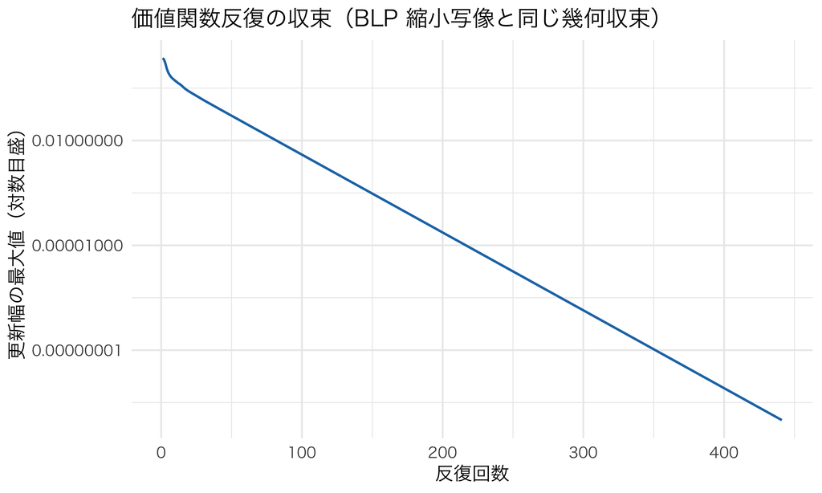

価値関数反復の収束。誤差が対数目盛でほぼ直線に落ちる = 幾何収束（縮小係数 = beta）。

```r
df_conv <- data.frame(iter = seq_along(sol$errs), err = sol$errs)
ggplot(df_conv, aes(iter, err)) +
  geom_line(color = "#1f77b4", linewidth = 0.8) +
  scale_y_log10() +
  labs(title = "価値関数反復の収束（BLP 縮小写像と同じ幾何収束）",
       x = "反復回数", y = "更新幅の最大値（対数目盛）")
```

```r
# 更新幅の比が beta に近づくことを確認
ratios <- sol$errs[6:15] / sol$errs[5:14]
cat("更新幅の比（beta=0.95 に近づくはず）:", round(ratios, 3), "\n")
```

```
更新幅の比（beta=0.95 に近づくはず）: 0.843 0.88 0.91 0.921 0.927 0.929 0.929 0.938 0.939 0.921
```

解けた価値関数 $V(x)$ と、そこから出る交換確率 $P(\text{交換} \mid x)$ を見る。走行距離が伸びるほど交換確率が上がる**S字カーブ**が出るはずだ。「もう十分走った、そろそろ載せ替えよう」という直感が、DP の解として現れる。

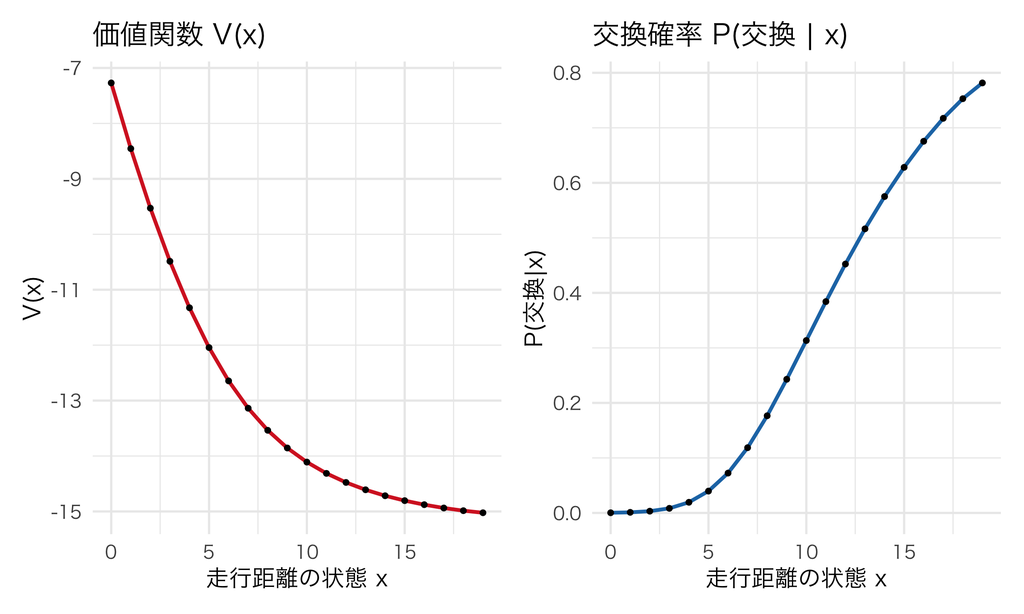

解けた価値関数 V(x) と交換確率 P(交換|x)。距離が伸びるほど交換確率が上がる S 字。

```r
library(patchwork)
Pr <- ccp_replace(sol$v0, sol$v1)

p_V <- ggplot(data.frame(x = xs, V = sol$V), aes(x, V)) +
  geom_line(color = "#d62728", linewidth = 1) + geom_point(size = 1) +
  labs(title = "価値関数 V(x)", x = "走行距離の状態 x", y = "V(x)")

p_P <- ggplot(data.frame(x = xs, P = Pr), aes(x, P)) +
  geom_line(color = "#1f77b4", linewidth = 1) + geom_point(size = 1) +
  labs(title = "交換確率 P(交換 | x)", x = "走行距離の状態 x", y = "P(交換|x)")

p_V + p_P
```

```r
cat("P(交換|x) が単調増加:", all(diff(Pr) >= -1e-12), "\n")
```

```
P(交換|x) が単調増加: TRUE
```

```r
cat("P(交換|x) の例（x=0,5,10,15,19）:", round(Pr[c(1, 6, 11, 16, 20)], 4), "\n")
```

```
P(交換|x) の例（x=0,5,10,15,19）: 0.0003 0.0397 0.3134 0.6282 0.7816
```

交換確率は $x=0$ ではほぼゼロ（$\approx 0.0003$）、$x=19$ では $\approx 0.78$ まで上がる。DP は「早すぎる交換は交換費の無駄、遅すぎる維持は維持費の膨張」というトレードオフを解いて、この滑らかな交換方針を導いた。

## Rシミュ2：データを生成する

推定に進む前に、この方針に従って動く「バス群」のパネルデータを作る。**200台のバス**を、それぞれ**100ヶ月**追跡する。各期、各バスは自分の走行距離状態を見て、交換確率 $P(\text{交換}\mid x)$ に従って交換するかを決め、状態が遷移していく。

```r
# パネルシミュレーション：n_bus 台 x n_month ヶ月
simulate_panel <- function(n_bus, n_month, theta1, RC, burn = 50) {
  sol <- solve_vfi(theta1, RC, tol = 1e-10)
  Pr  <- ccp_replace(sol$v0, sol$v1)
  total_T <- n_month + burn
  X <- matrix(0L, n_bus, total_T)   # 走行距離状態（値 0..K-1 を格納）
  A <- matrix(0L, n_bus, total_T)   # 行動（0=維持, 1=交換）
  x <- sample(0:(K - 1), n_bus, replace = TRUE)   # 初期状態をランダムに
  for (t in 1:total_T) {
    u <- runif(n_bus)
    a <- as.integer(u < Pr[x + 1])                # 状態 x の交換確率で判定
    X[, t] <- x
    A[, t] <- a
    jump <- sample(0:2, n_bus, replace = TRUE, prob = p_trans)   # 距離の進み
    x <- ifelse(a == 1L, pmin(0 + jump, K - 1), pmin(x + jump, K - 1))
  }
  # burn-in を捨てて定常に近い部分だけ返す
  list(X = X[, (burn + 1):total_T], A = A[, (burn + 1):total_T])
}

n_bus <- 200; n_month <- 100
panel <- simulate_panel(n_bus, n_month, theta1_true, RC_true)
X <- panel$X; A <- panel$A

cat("パネルのセル数:", length(X), "（", n_bus, "台 x", n_month, "ヶ月 ）\n")
```

```
パネルのセル数: 20000 （ 200 台 x 100 ヶ月 ）
```

```r
cat("全体の交換率:", round(mean(A), 4), "\n")
```

```
全体の交換率: 0.0941
```

```r
cat("平均走行距離（全セル）:", round(mean(X), 3), "\n")
```

```
平均走行距離（全セル）: 5.095
```

交換でリセットされる **replacement cycle（載せ替えサイクル）**を可視化しよう。数台ぶんの走行距離の軌跡を描くと、じわじわ距離が伸びては、交換でストンと0付近に戻る「のこぎり歯」のパターンが見える。

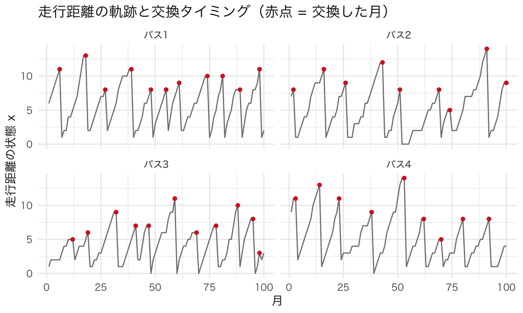

数台のバスの走行距離の軌跡。距離が伸びては、交換でリセットされる（のこぎり歯 = replacement cycle）。

```r
show_bus <- c(1, 2, 3, 4)
df_traj <- do.call(rbind, lapply(show_bus, function(b) {
  data.frame(month = 1:n_month, mileage = X[b, ], bus = paste0("バス", b),
             replace = A[b, ])
}))
ggplot(df_traj, aes(month, mileage)) +
  geom_line(color = "grey50") +
  geom_point(data = subset(df_traj, replace == 1), aes(month, mileage),
             color = "#d62728", size = 1.6) +
  facet_wrap(~ bus, ncol = 2) +
  labs(title = "走行距離の軌跡と交換タイミング（赤点 = 交換した月）",
       x = "月", y = "走行距離の状態 x")
```

赤い点（交換した月）が、走行距離の高いところで打たれ、その直後に距離が0付近へ落ちているのが分かる。これが Zurcher の判断記録に相当する「観測データ」だ。実データでは、我々はこの $(X, A)$ しか見えず、$\theta_1$ や $RC$ は知らない。それを推定するのが仕事だ。

状態ごとの交換頻度が、モデルの交換確率とどれくらい一致するかも見ておこう（これが後の CCP 推定の入力になる）。

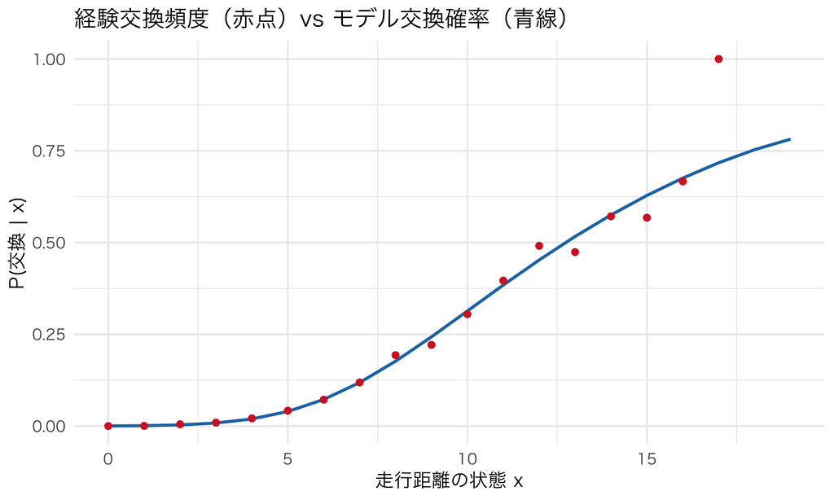

状態ごとの経験交換頻度（点）とモデルの交換確率（線）。よく一致している。

```r
freq_by_state <- sapply(0:(K - 1), function(xv) {
  mask <- (X == xv)
  if (sum(mask) > 0) mean(A[mask]) else NA_real_
})
count_by_state <- sapply(0:(K - 1), function(xv) sum(X == xv))

df_freq <- data.frame(x = xs, emp = freq_by_state, model = Pr, n = count_by_state)
ggplot(df_freq, aes(x)) +
  geom_line(aes(y = model), color = "#1f77b4", linewidth = 1) +
  geom_point(aes(y = emp), color = "#d62728", size = 1.8) +
  labs(title = "経験交換頻度（赤点）vs モデル交換確率（青線）",
       x = "走行距離の状態 x", y = "P(交換 | x)")
```

```r
cat("状態ごとの観測数:", count_by_state, "\n")
```

```
状態ごとの観測数: 813 2054 2234 2225 2139 2077 1935 1750 1517 1198 856 550 334 173 84 37 18 6 0 0
```

高走行距離の状態（$x = 14$ 以降）はデータが薄く、経験頻度がガタつく。逆に $x=0$ は「交換直後の新品」なので観測数は多いが、交換はまず起きない（経験頻度がほぼ0）。この「薄い／潰れる」問題は、Hotz-Miller のところで丁寧に扱う。

## 推定1：NFXP（Rust の方法）

いよいよ推定だ。観測データ $(X, A)$ から、深層パラメータ $\theta = (\theta_1, RC)$ を最尤法で推定する。ここで Rust が使った**Nested Fixed Point algorithm（NFXP、入れ子固定点アルゴリズム）**を実装する。名前は仰々しいが、構造はシンプルな**二重ループ**だ。

- **外側（outer loop）**：最適化アルゴリズムが $\theta = (\theta_1, RC)$ を提案する。
- **内側（inner loop）**：提案された $\theta$ に対して、価値関数反復で DP を**解き切って**、各状態の choice-specific value $v(x,0), v(x,1)$ を得る。
- その $v$ から logit 尤度を計算し、外側に返す。外側はこれを最大化する $\theta$ を探す。

対数尤度は、各バス・各期について「実際にとった行動の確率の対数」を足し上げたものだ（第2回の logit 尤度と同じ形）：

$$\ell(\theta) = \sum_{\text{bus } i} \sum_{\text{month } t}
\Big[ a_{it} \log P(1 \mid x_{it}; \theta) + (1 - a_{it}) \log P(0 \mid x_{it}; \theta) \Big].$$

キモは「$P(a \mid x; \theta)$ を計算するのに、内側で毎回 DP を解き切る」点だ。外側が $\theta$ を1回提案するたびに、内側で価値関数反復が丸ごと1回走る。**これが NFXP の計算的な重さの正体**である。

```r
# NFXP の負の対数尤度。theta = (theta1, RC)。内側で VFI を解き切る。
neg_loglik_nfxp <- function(theta, X, A) {
  theta1 <- theta[1]; RC <- theta[2]
  if (theta1 <= 0 || RC <= 0) return(1e10)   # パラメータは正
  sol <- solve_vfi(theta1, RC, tol = 1e-8, maxit = 1000)   # ← 内側で DP を解き切る
  # 数値安定な log P：logaddexp(v0, v1)
  m   <- pmax(sol$v0, sol$v1)
  lae <- m + log(exp(sol$v0 - m) + exp(sol$v1 - m))   # log(exp v0 + exp v1)
  logp1 <- sol$v1 - lae     # log P(交換|x)
  logp0 <- sol$v0 - lae     # log P(維持|x)
  xr <- as.vector(X) + 1    # 状態を 1-index に
  ar <- as.vector(A)
  ll <- sum(ifelse(ar == 1L, logp1[xr], logp0[xr]))
  -ll
}

# 外側の最適化（Nelder-Mead）。実行時間を測る。
t0 <- Sys.time()
fit_nfxp <- optim(par = c(0.10, 5.0), fn = neg_loglik_nfxp,
                  X = X, A = A, method = "Nelder-Mead",
                  control = list(reltol = 1e-9, maxit = 2000),
                  hessian = TRUE)
t1 <- Sys.time()
nfxp_time <- as.numeric(difftime(t1, t0, units = "secs"))

theta_hat_nfxp <- fit_nfxp$par
cat("NFXP 推定値 (theta1, RC):", round(theta_hat_nfxp, 4), "\n")
```

```
NFXP 推定値 (theta1, RC): 0.1467 7.826
```

```r
cat("真値            (theta1, RC):", c(theta1_true, RC_true), "\n")
```

```
真値            (theta1, RC): 0.15 8
```

```r
cat("NFXP の実行時間:", round(nfxp_time, 2), "秒\n")
```

```
NFXP の実行時間: 0.36 秒
```

標準誤差は、第2回と同じく、最尤推定量の Hessian（の逆行列）から得る。`optim` に `hessian = TRUE` を渡すと、負の対数尤度の Hessian が返ってくるので、その逆行列が分散共分散行列になる。

```r
vcov_nfxp <- solve(fit_nfxp$hessian)
se_nfxp   <- sqrt(diag(vcov_nfxp))

recovery_nfxp <- data.frame(
  parameter = c("theta1（維持費の傾き）", "RC（交換費）"),
  truth     = c(theta1_true, RC_true),
  estimate  = round(theta_hat_nfxp, 4),
  se        = round(se_nfxp, 4),
  ci_lower  = round(theta_hat_nfxp - 1.96 * se_nfxp, 4),
  ci_upper  = round(theta_hat_nfxp + 1.96 * se_nfxp, 4)
)
kable(recovery_nfxp, caption = "NFXP：真値回収と標準誤差（真値は 95%CI 内）")
```

NFXP：真値回収と標準誤差（真値は 95%CI 内）

| parameter | truth | estimate | se | ci_lower | ci_upper |
| --- | --- | --- | --- | --- | --- |
| theta1（維持費の傾き） | 0.15 | 0.1467 | 0.0045 | 0.1379 | 0.1556 |
| RC（交換費） | 8.00 | 7.8260 | 0.1856 | 7.4622 | 8.1898 |

真値 $(\theta_1, RC) = (0.15, 8.0)$ が、いずれも95%信頼区間の中に回収された。動学モデルでも、DGP を書いてシミュレーションし、真値を回収できることを確認する——この「真値回収」の作法は、推定手法がどれだけ複雑になっても変わらない。

**警告NFXP の計算的な重さを体感する**

## 推定2：選択確率を使うCCPアプローチ

NFXP の重さは、突き詰めれば「**価値関数を毎回解いている**」ことに尽きる。Hotz and Miller (1993) の発想は、逆転の一手だ。

> 価値関数を解かずに、**データの選択確率（conditional choice probability, CCP）から、価値の差を逆算する**。

なぜそんなことができるのか。T1EV のもとでは、選択確率と価値の間に、**閉じた関係式**があるからだ。二値選択（維持 vs 交換）の場合、logit の反転から

$$\log P(1 \mid x) - \log P(0 \mid x) = v(x, 1) - v(x, 0).$$

「交換確率と維持確率の対数の差」が、そのまま「choice-specific value の差」に等しい。**データから CCP を頻度で推定できれば、左辺は観測できる。すると右辺の $v(x,1) - v(x,0)$ が、価値関数を解かずに手に入る。**

だが、$v(x,1) - v(x,0)$ には将来項が残っている：

$$v(x,1) - v(x,0) = \big[u(x,1) - u(x,0)\big] + \beta\Big(\mathbb{E}[V(x') \mid x, 1] - \mathbb{E}[V(x') \mid x, 0]\Big).$$

将来価値 $V$ が残っているなら、結局 $V$ を解かないといけないのでは？——ここで、このモデルの交換行動に特有の性質を使う。

### 交換は renewal action：finite dependence で将来項が消える

思い出そう。**交換（$a=1$）すると、状態は現在の $x$ によらず $x=0$ にリセットされる**（$P_1$ の全行が同じだった）。これを **renewal action（更新行動）**と呼ぶ。renewal action があると、将来項が驚くほど簡単に打ち消せる。これを **finite dependence（有限依存）**という。

具体的にこのモデルで導出しよう。Hotz-Miller の補題より、任意の行動 $a$ を使って価値を書き直せる。とくに**次期状態 $x'$ で「交換」を選んだ**ときの表現を使うと：

$$V(x') = v(x', 1) + \gamma - \log P(1 \mid x').$$

（logit の反転：$V(x) = v(x,a) + \gamma - \log P(a\mid x)$ が任意の $a$ で成り立つ。導出は下の callout。）

ここで $v(x', 1) = u(x', 1) + \beta\, \mathbb{E}[V(x'') \mid x', 1]$。そして交換は $x'$ によらず $x=0$ にリセットするので、$\mathbb{E}[V(x'') \mid x', 1]$ は**$x'$ に依存しない定数**（$\bar{W}$ と呼ぶ）になる。したがって

$$V(x') = \underbrace{-RC + \beta \bar{W} + \gamma}_{\text{$x'$ によらない定数}} - \log P(1 \mid x').$$

これを $v(x,1) - v(x,0)$ の将来項に代入する。定数部分は、$\mathbb{E}[\cdot \mid x, 1]$ と $\mathbb{E}[\cdot \mid x, 0]$ のどちらでも「確率の和 = 1」なので、**差をとると綺麗に消える**。残るのは $-\log P(1\mid x')$ の項だけ：

$$\mathbb{E}[V(x') \mid x, 1] - \mathbb{E}[V(x') \mid x, 0]
= -\sum_{x'} \big[P_1(x'\mid x) - P_0(x'\mid x)\big] \log P(1 \mid x').$$

$V$ が消えた！ 残ったのは、遷移確率（既知）と CCP（データから推定可能）だけ。これらを全部代入すると、$u(x,1) - u(x,0) = \theta_1 x - RC$ を使って、**線形回帰の形**になる：

$$\underbrace{\log P(1\mid x) - \log P(0\mid x) + \beta \sum_{x'}\big[P_1 - P_0\big](x'\mid x)\,\log P(1\mid x')}_{=:\ y(x)\ \text{（データから計算できる）}}
\;=\; \theta_1\, x - RC.$$

左辺 $y(x)$ を、経験 CCP $\hat P(1\mid x)$ から状態ごとに計算し、それを $x$ に回帰する。**傾きが $\theta_1$、切片が $-RC$**。価値関数反復は一切登場しない。最適化すらいらない（ただの OLS だ）。

**ノート導出：Hotz-Miller の反転 $V(x) = v(x,a) + \gamma - \log P(a\mid x)$**

T1EV のもとで、$V(x) = \log\sum_{a'} e^{v(x,a')} + \gamma$（logsum）であり、$P(a\mid x) = e^{v(x,a)} / \sum_{a'} e^{v(x,a')}$（logit）だった。後者から $\log P(a\mid x) = v(x,a) - \log\sum_{a'} e^{v(x,a')}$、すなわち $\log\sum_{a'} e^{v(x,a')} = v(x,a) - \log P(a\mid x)$。これを logsum の式に代入すると

$$V(x) = v(x,a) - \log P(a\mid x) + \gamma.$$

任意の $a$ で成り立つ（左辺は $a$ によらないので、右辺の $a$ 依存が打ち消し合う）。これが Hotz-Miller の「CCP から価値を復元する」核心の恒等式だ。この式のおかげで、$V$ を「観測できる CCP」で書き換えられる。renewal action があると、書き換えた先の将来項がさらに定数化して消える——これが finite dependence の仕組みである。

まず**恒等式が本当に成り立つか**を、真の CCP（DP を解いて得た $P(1\mid x)$）で確認しよう。左辺 $y(x)$ が、本当に $\theta_1 x - RC$ に一致すれば、導出が正しいことの決定的な証拠になる。

```r
# 真の CCP で finite-dependence 恒等式を検算する
diffP <- P1 - P0                       # (K x K) 各行 x
sol_true <- solve_vfi(theta1_true, RC_true, tol = 1e-12)   # 真値で DP を精密に解く
P1c <- ccp_replace(sol_true$v0, sol_true$v1)               # 真の CCP P(交換|x)
P0c <- 1 - P1c
logP1 <- log(P1c); logP0 <- log(P0c)

# y(x) = [logP1 - logP0] + beta * (P1 - P0) 行 x logP1
y_true <- logP1 - logP0 + beta * as.vector(diffP %*% logP1)
target <- theta1_true * xs - RC_true    # あるべき値

cat("恒等式の最大誤差 max|y - (theta1*x - RC)|:", max(abs(y_true - target)), "\n")
```

```
恒等式の最大誤差 max|y - (theta1*x - RC)|: 2.664535e-15
```

```r
# y を (1, x) に回帰 → 傾き=theta1, 切片=-RC
fit_check <- lm(y_true ~ xs)
cat("検算：theta1 =", round(coef(fit_check)[2], 6),
    " RC =", round(-coef(fit_check)[1], 6), "（真値 0.15, 8.0）\n")
```

```
検算：theta1 = 0.15  RC = 8 （真値 0.15, 8.0）
```

恒等式は機械精度（$10^{-14}$ オーダー）で成立し、真値 $(\theta_1, RC) = (0.15, 8.0)$ をぴたりと復元した。導出は正しい。「価値関数を解かずに、CCP から深層パラメータへ」が、このモデルでは本当にただの線形回帰になる。

### データの頻度 CCP で推定する

次は実践だ。真の CCP は使えない（それは知りたい答えの一部）。代わりに、観測データから**頻度で CCP を推定**する：$\hat P(1\mid x) = (\text{状態 } x \text{ で交換した回数}) / (\text{状態 } x \text{ の観測回数})$。

ここで前に見た問題が効く。$x=0$ では交換頻度がほぼ0で、$\log \hat P(1\mid x)$ が $-\infty$ に飛ぶ。高走行距離の状態は観測が薄く、頻度がガタつく。ここでは教育用に2つの安定化を施す：(1) $\hat P=(n_1+0.5)/(n+1)$ という**Jeffreys/add-half smoothing**を使う（Laplace/add-oneなら $(n_1+1)/(n+2)$）、(2) 観測数が十分ある状態だけをWLSに使う。閾値や平滑化は推定法の本質ではなく、実務では帯域・series/logitによる第一段階と感度分析が必要である。

```r
# 状態ごとの交換回数 n1 と観測回数 n
n_x  <- sapply(0:(K - 1), function(xv) sum(X == xv))
n1_x <- sapply(0:(K - 1), function(xv) sum(A[X == xv]))

# Jeffreys/add-half 平滑化した CCP
Psm  <- (n1_x + 0.5) / (n_x + 1.0)
logP1h <- log(Psm); logP0h <- log(1 - Psm)

# 将来項には全到達状態の logP1 が必要。未観測状態は最も近い観測状態で補完。
logP1h_full <- logP1h
observed_idx <- which(n_x > 0)
if (length(observed_idx) == 0) stop("CCPを計算できる観測状態がない")
for (idx in which(n_x == 0)) {
  nearest <- observed_idx[which.min(abs(observed_idx - idx))]
  logP1h_full[idx] <- logP1h[nearest]
}

# y(x) をデータの CCP で計算
y_hat <- logP1h - logP0h + beta * as.vector(diffP %*% logP1h_full)

# 観測数 >= 30 の状態だけ、観測数で重み付けして回帰（WLS）
good <- n_x >= 30
t0 <- Sys.time()
fit_ccp <- lm(y_hat ~ xs, weights = n_x, subset = good)
t1 <- Sys.time()
ccp_time <- as.numeric(difftime(t1, t0, units = "secs"))

theta1_ccp <- as.numeric(coef(fit_ccp)[2])
RC_ccp     <- as.numeric(-coef(fit_ccp)[1])
cat("CCP 推定値：theta1 =", round(theta1_ccp, 4), " RC =", round(RC_ccp, 4), "\n")
```

```
CCP 推定値：theta1 = 0.1514  RC = 7.9716
```

```r
cat("使った状態数:", sum(good), " / ", K, "\n")
```

```
使った状態数: 16  /  20
```

```r
cat("CCP の実行時間:", signif(ccp_time, 3), "秒（回帰1本）\n")
```

```
CCP の実行時間: 0.00545 秒（回帰1本）
```

CCP 推定は、$\theta_1 \approx 0.15$、$RC \approx 8$ 近傍を回収する（乱数の引かれ方で $\pm 0.5$ 程度は揺れる。ここが CCP の弱点＝ノイズで、後述する）。そして**実行時間は回帰1本、事実上ゼロ秒**だ。価値関数反復を一度も回していない。

### NFXP と CCP を並べる

2つの推定法を、推定値と計算時間で直接比べる。

```r
compare_tbl <- data.frame(
  method   = c("NFXP (Rust)", "CCP (Hotz-Miller)"),
  theta1   = round(c(theta_hat_nfxp[1], theta1_ccp), 4),
  RC       = round(c(theta_hat_nfxp[2], RC_ccp), 4),
  time_sec = signif(c(nfxp_time, ccp_time), 3),
  DP_solve = c("毎評価で解き切る", "一度も解かない")
)
kable(compare_tbl, caption = "NFXP vs CCP：推定値と計算時間",
      row.names = FALSE)
```

NFXP vs CCP：推定値と計算時間

| method | theta1 | RC | time_sec | DP_solve |
| --- | --- | --- | --- | --- |
| NFXP (Rust) | 0.1467 | 7.8260 | 0.35600 | 毎評価で解き切る |
| CCP (Hotz-Miller) | 0.1514 | 7.9716 | 0.00545 | 一度も解かない |

```r
# 速度比（ccp_time が測定精度以下でも安定するよう下限を置く）
speed_ratio <- nfxp_time / max(ccp_time, 1e-4)
cat("CCP は NFXP のおよそ", format(round(speed_ratio), big.mark = ","),
    "分の1の時間で、近い答えを出した（回帰1本 vs DP を何十回も解き直す）。\n")
```

```
CCP は NFXP のおよそ 65 分の1の時間で、近い答えを出した（回帰1本 vs DP を何十回も解き直す）。
```

**重要推定値と計算時間を比較する**

- **NFXP**：外側の最適化 × 内側の価値関数反復。「$\theta$ を1回変えるたびに DP を丸ごと解き直す」ので重い。状態の数が多いほど、計算時間が長くなる。
- **CCP**：データから CCP を頻度推定 → renewal action の finite dependence で将来項を消す → 線形回帰1本。**DP を一度も解かない**。この例では計算量を大きく減らせる。

代償は第一段階でCCPを推定するノイズである。この単純な頻度CCP＋WLSは、正しく指定されたfull-solution MLEより一般に効率が低く、薄い状態で不安定になる。ただし「CCP法は必ずこの回帰」「必ず一定の効率順位」という意味ではない。最適な重み付けや反復擬似尤度で改善できる。実務ではCCPで当たりをつけ、NPLなどで更新する選択肢がある。

**ノートCCP のノイズについて正直に**

上の1回の推定はたまたま真値に近かったが、頻度推定・平滑化・薄い状態の切り捨てにより有限標本のノイズとバイアスが出る。Hotz and Miller (1993) が示した要点は、条件の下でCCPを代入した構造パラメータ推定量が**一致性と漸近正規性**を持つことである。これはNFXP/MLEと同じ推定量・同じ漸近分散という意味ではない。本講義の簡便WLSのばらつきは、標本を繰り返して確認する。

## 識別と反実仮想

### 何が識別され、何が識別されないか

動学モデルの識別には、静学にはない固有の難所がある。

**割引因子 $\beta$ は、普通は識別が難しい。** 直感的には、$\beta$（将来をどれだけ重視するか）と flow utility の形（今日のコスト）が**もつれて**しまうからだ。「早めに交換する」という行動は、「交換費 $RC$ が安い」からかもしれないし、「$\beta$ が大きくて将来の維持費を強く恐れている」からかもしれない。この2つを、選択データだけから分離するのは一般に困難だ。そこで実務では、**$\beta$ を外から与えて固定する**（今回は $0.95$）のが標準的な慣習になっている。金利や意思決定の頻度から、$\beta$ を先験的に決めるわけだ。

**効用の水準は正規化が要る。** 静学 logit で outside option の効用を0に置いたのと同じで、動学でも効用の絶対水準には意味がなく、差だけが識別される。ここでは維持の flow utility を $-\theta_1 x$、交換を $-RC$ と置くことで、水準を固定している。

### 交換費に補助が出た場合を計算する

維持費と交換費のパラメータ $(\theta_1,RC)$ が推定できたので、交換費に補助が出る場合を計算しよう。第4回の合併分析と同じく、何を変えて何を固定するかを先に決める。ここでは補助によって意思決定者が負担する交換費だけが下がり、維持費の係数や走行距離の遷移は変わらないと仮定する。

問い：**もし政府（あるいは本社）が、エンジン交換費 $RC$ を20%補助したら、交換頻度と平均走行距離はどう変わるか。**

これは観測データには無い状況（$RC$ を人為的に下げた世界）だ。このモデルでは、補助が費用だけを変え、$\theta_1$ や遷移は変えないと仮定する。その仮定のもとで $RC$ を $0.8 \times RC$ に置き換えて **DP を解き直し**、新しい交換方針のもとでの長期的な状態分布を計算する。

長期的な交換頻度・平均走行距離は、新しい交換方針が誘導するマルコフ連鎖の**定常分布（ergodic distribution）**から計算する。定常分布 $d$ は、状態遷移行列 $M$（方針込み）に対して $d = d\,M$ を満たすベクトルだ。

```r
# 方針（交換確率 Pr）が誘導する状態遷移行列 M と、その定常分布
policy_transition <- function(Pr) {
  # 状態 x から：確率 Pr で交換（P1 の行）、1-Pr で維持（P0 の行）
  (1 - Pr) * P0 + Pr * P1        # 各行を Pr[x], (1-Pr[x]) で重み付け（R のリサイクルに注意）
}
ergodic_dist <- function(M) {
  # d M = d, sum d = 1 を解く（(M' - I) の零空間 + 正規化）
  A <- rbind(t(M) - diag(K), rep(1, K))
  b <- c(rep(0, K), 1)
  d <- qr.solve(A, b)             # 最小二乗で解く
  d / sum(d)
}

summarize_policy <- function(theta1, RC, label, bta = beta) {
  s  <- solve_vfi(theta1, RC, tol = 1e-10, bta = bta)
  Pr <- ccp_replace(s$v0, s$v1)
  M  <- policy_transition(Pr)
  d  <- ergodic_dist(M)
  rep_rate <- sum(d * Pr)         # 長期交換率
  mean_mi  <- sum(d * xs)         # 長期平均走行距離
  cat(sprintf("  %s：長期交換率 = %.4f, 平均走行距離 = %.3f\n", label, rep_rate, mean_mi))
  list(rep_rate = rep_rate, mean_mi = mean_mi, d = d, Pr = Pr)
}

cat("反実仮想：交換費 RC を 20% 補助（推定した動学モデルで解き直す）\n")
```

```
反実仮想：交換費 RC を 20% 補助（推定した動学モデルで解き直す）
```

```r
base_cf <- summarize_policy(theta_hat_nfxp[1], theta_hat_nfxp[2], "補助前")
```

```
  補助前：長期交換率 = 0.0939, 平均走行距離 = 5.087
```

```r
sub_cf  <- summarize_policy(theta_hat_nfxp[1], theta_hat_nfxp[2] * 0.8, "20%補助後")
```

```
  20%補助後：長期交換率 = 0.1105, 平均走行距離 = 4.467
```

```r
cat(sprintf("  => 交換率:   %.4f -> %.4f  (%+.1f%%)\n",
            base_cf$rep_rate, sub_cf$rep_rate,
            (sub_cf$rep_rate / base_cf$rep_rate - 1) * 100))
```

```
  => 交換率:   0.0939 -> 0.1105  (+17.7%)
```

```r
cat(sprintf("  => 平均走行距離: %.3f -> %.3f  (%+.1f%%)\n",
            base_cf$mean_mi, sub_cf$mean_mi,
            (sub_cf$mean_mi / base_cf$mean_mi - 1) * 100))
```

```
  => 平均走行距離: 5.087 -> 4.467  (-12.2%)
```

推定したモデルでは、交換費を20%補助すると、長期交換率は 9.4% から 11.0% へ上昇し、平均走行距離の状態は 5.09 から 4.47 へ低下する。交換が安くなると、より頻繁に、走行距離が短いうちにエンジンを載せ替えるようになる。補助前後の状態分布も比較しよう。

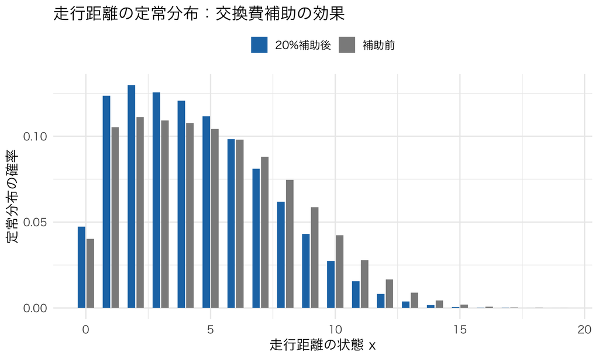

交換費 20% 補助の前後で、走行距離の定常分布がどう変わるか。補助後は低走行距離側に寄る。

```r
df_cf <- rbind(
  data.frame(x = xs, dens = base_cf$d, policy = "補助前"),
  data.frame(x = xs, dens = sub_cf$d,  policy = "20%補助後")
)
ggplot(df_cf, aes(x, dens, fill = policy)) +
  geom_col(position = position_dodge(width = 0.7), width = 0.6) +
  scale_fill_manual(values = c("補助前" = "grey55", "20%補助後" = "#1f77b4")) +
  labs(title = "走行距離の定常分布：交換費補助の効果",
       x = "走行距離の状態 x", y = "定常分布の確率", fill = NULL) +
  theme(legend.position = "top")
```

### myopic（$\beta = 0$）で推定すると反実仮想を外す

ここで、動学を無視する危険を数値で見せる。もし分析者が「消費者は近視眼的（myopic）で、将来を一切見ない」と誤って仮定し、$\beta = 0$ でパラメータを推定したら、どうなるか。

$\beta = 0$ だと、choice-specific value は将来項が消えて $v(x,0) = -\theta_1 x$、$v(x,1) = -RC$ になる。これはただの**静学 logit** だ。この静学モデルを、実は forward-looking な Zurcher が生成したデータに当てはめると、パラメータが歪む。

```r
# 大きめの標本で myopic の系統的バイアスを見る（ノイズではなく偏りを見たい）
panel_big <- simulate_panel(2000, 300, theta1_true, RC_true)
Xb <- panel_big$X; Ab <- panel_big$A

# myopic (beta=0) の logit MLE：v0=-theta1*x, v1=-RC を直接使う
neg_loglik_myopic <- function(theta, X, A) {
  theta1 <- theta[1]; RC <- theta[2]
  if (theta1 <= 0 || RC <= 0) return(1e10)
  v0 <- -theta1 * xs; v1 <- rep(-RC, K)
  m  <- pmax(v0, v1)
  lae <- m + log(exp(v0 - m) + exp(v1 - m))
  logp1 <- v1 - lae; logp0 <- v0 - lae
  xr <- as.vector(X) + 1; ar <- as.vector(A)
  -sum(ifelse(ar == 1L, logp1[xr], logp0[xr]))
}
fit_myopic <- optim(c(0.10, 5.0), neg_loglik_myopic, X = Xb, A = Ab,
                    method = "Nelder-Mead", control = list(reltol = 1e-9))
# 参照：同じ大標本での動学（正しい）推定
fit_dyn_big <- optim(c(0.10, 5.0), neg_loglik_nfxp, X = Xb, A = Ab,
                     method = "Nelder-Mead", control = list(reltol = 1e-9))

est_tbl <- data.frame(
  model  = c("真値", "動学 (beta=0.95, 正しい)", "myopic (beta=0, 誤り)"),
  theta1 = round(c(theta1_true, fit_dyn_big$par[1], fit_myopic$par[1]), 4),
  RC     = round(c(RC_true,     fit_dyn_big$par[2], fit_myopic$par[2]), 4)
)
kable(est_tbl, caption = "同じデータを動学 vs myopic で推定：myopic は theta1 を大きく歪める",
      row.names = FALSE)
```

同じデータを動学 vs myopic で推定：myopic は theta1 を大きく歪める

| model | theta1 | RC |
| --- | --- | --- |
| 真値 | 0.1500 | 8.0000 |
| 動学 (beta=0.95, 正しい) | 0.1500 | 8.0053 |
| myopic (beta=0, 誤り) | 0.4564 | 5.4190 |

myopic モデルは、$\theta_1$ を真値の**3倍近く**に過大推定してしまう。理由はこうだ。データの交換確率が走行距離に対して立ち上がる勾配を、forward-looking モデルは「将来の維持費を恐れて早めに交換する」で一部説明する。だが myopic モデルには将来項が無いので、**同じ勾配を全部 flow utility の傾き $\theta_1$ に押し付ける**しかない。結果、$\theta_1$ が水増しされる。

この歪んだパラメータで反実仮想を回すと、答えも外れる。myopic 分析者は、自分のモデル（$\beta=0$）で補助の効果を予測する。

```r
cat("反実仮想（RC 20%補助）の予測：正しい動学 vs myopic\n")
```

```
反実仮想（RC 20%補助）の予測：正しい動学 vs myopic
```

```r
# 正しい動学：真の theta を、正しい beta=0.95 の DP で解いて予測
truth0 <- summarize_policy(theta1_true, RC_true,       "真実 補助前")
```

```
  真実 補助前：長期交換率 = 0.0934, 平均走行距離 = 5.098
```

```r
truth1 <- summarize_policy(theta1_true, RC_true * 0.8, "真実 補助後")
```

```
  真実 補助後：長期交換率 = 0.1098, 平均走行距離 = 4.478
```

```r
# myopic 分析者：歪んだ推定 theta を、自分のモデル（beta=0）で解いて予測
myo0 <- summarize_policy(fit_myopic$par[1], fit_myopic$par[2],       "myopic 補助前", bta = 0)
```

```
  myopic 補助前：長期交換率 = 0.0943, 平均走行距離 = 5.129
```

```r
myo1 <- summarize_policy(fit_myopic$par[1], fit_myopic$par[2] * 0.8, "myopic 補助後", bta = 0)
```

```
  myopic 補助後：長期交換率 = 0.1245, 平均走行距離 = 4.089
```

```r
cf_compare <- data.frame(
  analysis = c("正しい動学", "myopic (誤り)"),
  rep_before = round(c(truth0$rep_rate, myo0$rep_rate), 4),
  rep_after  = round(c(truth1$rep_rate, myo1$rep_rate), 4),
  rep_change_pct = round(c((truth1$rep_rate / truth0$rep_rate - 1) * 100,
                           (myo1$rep_rate / myo0$rep_rate - 1) * 100), 1)
)
kable(cf_compare, caption = "RC 20%補助の効果予測：myopic は交換率の増加を大きく過大評価",
      row.names = FALSE)
```

RC 20%補助の効果予測：myopic は交換率の増加を大きく過大評価

| analysis | rep_before | rep_after | rep_change_pct |
| --- | --- | --- | --- |
| 正しい動学 | 0.0934 | 0.1098 | 17.6 |
| myopic (誤り) | 0.0943 | 0.1245 | 32.1 |

交換率の増加は、真の動学モデルでは17.6%、myopicモデルでは32.1%となった。同じ購買・交換履歴に当てはめても、将来価値を省いたモデルは、その影響を当期効用の係数に含めてしまう。その係数を使って補助の効果を計算すると、政策への反応まで変わる。これは、第4回で異質性や代替性の指定によって合併の予測が変わったことと、同じ種類の問題である。

## 動学モデルで何が分かり、何を仮定しているか

動学モデルを使うことで計算できる反実仮想が増える。その分、将来の予想や状態遷移についての仮定も必要になる。

**利点：政策不変性が信頼できる範囲で反実仮想を構成できる。** flow utility のパラメータ $(\theta_1, RC)$ を意思決定者の「好み・技術」と解釈し、補助は $RC$ だけを変えて $\theta_1$ や遷移を変えない、と仮定する。この仮定が妥当なら、$RC$ を人為的に動かした世界を同じ $\theta_1$ のもとでシミュレートできる。政策不変性は「深層」と名付ければ自動的に保証される性質ではなく、制度知識と感度分析で吟味すべき識別・外挿仮定である。

**状態の数と計算量。** 状態が多次元になると、価値関数反復の計算量が爆発する。NFXP はこれに真正面からぶつかる。CCP や、その発展（Aguirregabiria-Mira の擬似尤度、Arcidiacono-Ellickson の実践的手法）は、この計算負担を減らす方法である。

**割引因子の識別。** 上で見た通り、割引因子は選択データだけからは識別しにくく、固定する慣習になっている。$\beta$ の値を変えると推定も反実仮想も動くので、感度分析が要る。

**コスト3：モデル誤設定リスク。** 状態遷移や flow utility の形を間違えると、深層パラメータも反実仮想も歪む。myopic の例は「$\beta$ を間違えると壊れる」極端なケースだが、遷移確率や状態の離散化のミスも同様に効く。

**重要実務指針：静学で足りる問いには静学を、状態を動かすなら動学を**

- **今日の効用だけで説明できる選択**（今の価格・属性への反応、直近の代替パターン）なら、静学の logit/BLP（第2〜4回）で十分。速いし、識別も素直だ。
- **今日の選択が将来の関連状態を動かし、意思決定者がそれを予見する問い**（在庫、契約残期間、走行距離、ポイント残高、耐久財の保有年数を変える政策）では、forward-looking を無視すると予測を外しうる。このDGPでmyopicの反実仮想が大きくずれた例を思い出してほしい。

「動学が要るか」の判定は、**現在の選択が将来の状態と利得を動かし、意思決定者がそれを先読みするか**で決まる。棚の一回限りの値付けなら静学で足りることが多く、解約金の設計や買いだめ誘発のように将来行動が変わる問いでは動学を検討する。

## 実証研究コーナー

**ヒント実証研究コーナー：Rust (1987) — Harold Zurcher とバスエンジン**

**問い**：マディソン市バス公社の整備責任者 Harold Zurcher は、どんな費用構造のもとで、いつエンジンを載せ替えるかを決めているのか。それを構造モデルとして復元できるか。

**データ**：1970年代〜80年代前半のマディソン市バス公社の車両整備記録。各バスの累積走行距離とエンジン載せ替えを月次で追った、162台・15,406 bus-month observations。

**識別戦略・モデル**：まさに本講義のモデルだ。走行距離を状態、載せ替えを行動とし、Zurcher が「期待割引費用を最小化する」ように行動する動学的離散選択モデルを立てた。T1EV ショックで logit 構造を得て、NFXP（内側で価値関数反復、外側で最尤）で維持費・交換費のパラメータを推定した。

**主要な発見**：走行距離が伸びるほど交換確率が上がる S 字の交換方針が、データとよく整合することを示した。推定された費用構造のもとで、「もし維持費や交換費が違ったら交換行動がどう変わるか」という反実仮想を計算してみせた。**構造推定の枠組みで、たった一人の意思決定者の内部パラメータを復元し、政策シミュレーションを可能にした**——これが動学的離散選択という分野の出発点になった。

**なぜこの回と繋がるか**：今日の講義そのものの原典だ。バス公社の地味な台帳が、実証IO・quantitative marketing の動学分析すべての祖先である。

**ヒント実証研究コーナー：Hotz and Miller (1993) — CCP で価値関数を迂回する**

**問い**：動学的離散選択の推定で、毎回価値関数を解き切る（NFXP の）重さを避けられないか。選択確率から、価値関数を解かずにパラメータを推定できないか。

**データ・設定**：理論的な貢献が中心だが、女性のライフサイクルにおける避妊・出産の選択など、動学的な意思決定への応用も示した。

**識別戦略・モデル**：本講義で導出した**Hotz-Miller の反転**——$V(x) = v(x,a) + \gamma - \log P(a\mid x)$——を確立した。条件付き選択確率（CCP）と価値関数の間に閉じた関係があることを使い、CCP を頻度で推定してから、それを価値の代理として推定に流し込む。これにより、価値関数反復を回さずにパラメータを推定できる（本講義の renewal action の例が、その最も鮮やかな特殊ケース）。

**主要な発見**：真のCCPを非parametricな頻度推定量で置き換えた構造パラメータ推定量について、条件の下で一致性と漸近正規性を示した。計算負荷を大きく下げられるが、NFXPのfull-solution MLEと同じ漸近分散を持つと一般には言えない。今日の「回帰1本」は、renewal/finite-dependenceを加えた特に簡単な特殊例である。

**この講義との関係**：データから選択確率を推定し、そこから価値の差を取り出す方法の根拠になる。NFXPとの比較では、計算量を減らせることに加え、最初に推定した選択確率の誤差が次の推定に伝わることも確認したい。

**ヒント実証研究コーナー：Gowrisankaran and Rysman (2012) — 耐久財の動学需要**

**問い**：デジタルカメラ（カムコーダ）のような耐久財では、消費者は「今は高いから、値下がりを待とう」と**買い控える**。この forward-looking な購買延期を無視すると、需要弾力性や新製品の価値評価を誤る。動学需要をどう推定するか。

**データ**：米国のデジタルカムコーダ市場、複数年の製品ごとの価格・スペック・販売数の集計データ。技術進歩で品質が上がり価格が下がっていく、典型的な耐久財市場。

**識別戦略・モデル**：random coefficient logit需要に動学を組み込んだ。消費者は「今買う」か「待つ」かを将来の価格低下・品質向上の期待を織り込んで選び、持続的な嗜好異質性と**時間を通じたrepeat purchase**も許す。買ったら永久に市場から退出する一回限りモデルではない。

**主要な発見**：静学モデルは、耐久財の価格弾力性を系統的に誤る。動学を入れると、「値下がり期待による買い控え」が識別され、価格変化への反応がより現実的になった。新製品導入の便益評価も、動学を入れると変わる。

**なぜこの回と繋がるか**：今日の道具（forward-looking な状態依存の選択）を、一人の意思決定者（Zurcher）から**市場全体の消費者**へ拡張した好例だ。第4回の BLP と第13回の動学が合流する地点であり、次回（第14回）の買いだめ・state dependence への直接の橋渡しになる。

**ヒント実証研究コーナー：Aguirregabiria and Mira (2010) — 実務者のための地図**

**問い**：動学的離散選択の推定法は、NFXP・CCP・擬似尤度・その拡張と数多くある。実務者はどれを、いつ使うべきか。全体像を整理できないか。

**データ・設定**：サーベイ論文であり、特定のデータではなく、分野全体の手法を体系化する。

**識別戦略・モデル**：単一エージェントの動学（今日の Rust）から、複数エージェントの動学ゲーム（企業の参入退出・投資競争）まで、推定法を統一的に整理する。NFXP、Hotz-Miller の CCP、Aguirregabiria-Mira 自身の **NPL（nested pseudo-likelihood、擬似尤度を反復して効率を上げる）**、Bajari-Benkard-Levin などを、計算コストと統計的性質の軸で位置づける。

**主要な発見（この分野の指針として）**：full-solution MLE、2段階CCP、反復擬似尤度などを、計算負荷・第一段階誤差・統計効率の軸で整理する。単純な頻度CCPは速い反面ノイズを受けやすく、NPLはCCPを反復更新して改善を狙う。効率順位は仮定・重み付け・実装を明記して比較すべきである。

**なぜこの回と繋がるか**：今日学んだ NFXP と CCP を、より広い手法群の中に位置づける「地図」だ。動学構造推定を実務で使うなら、まずこのサーベイ（と Arcidiacono-Ellickson 2011 の実践ガイド）で全体像を掴むとよい。第15回の dynamic pricing（企業側の動学）へ進む前の、見取り図でもある。

## ビジネスの現場で

**ノートビジネスの現場で：設備保全・車両リプレースの意思決定支援**

Rust のバス問題は、比喩ではなく**そのまま現代の設備保全（predictive maintenance）**だ。工場の生産設備、航空機のエンジン、鉄道車両、社用車のフリート——「今リプレース／オーバーホールするか、あと1年使い倒すか」は、まさに走行距離（や稼働時間・故障履歴）を状態とする動学的離散選択である。IoT センサーで稼働データが取れる今、各設備の「状態」をリアルタイムに把握し、推定した維持費・交換費のもとで最適な載せ替えタイミングを提案するシステムが実際に動いている。「補助金や税制で設備更新を促したら、更新頻度がどう変わるか」という政策評価も、今日の反実仮想そのものだ。

**ノートビジネスの現場で：解約金のあるサブスク解約と、ポイント有効期限の設計**

「解約金があるサブスクの解約」は、典型的な forward-looking の意思決定だ。今解約すると違約金を払うが、契約を続ければ毎月の料金がかかる。合理的な顧客は「あと何ヶ月で無料期間・割引期間が終わるか」という**契約残期間という状態**を見て、今解約するか待つかを決める。だから「解約金を値上げしたら解約率がどう変わるか」という反実仮想には、動学が要る。静学モデルは「今月の効用」しか見ないので、契約残期間に応じた駆け込み解約・解約延期を捉えられず、政策効果を誤る。

**ポイント有効期限の設計**も同じ構造だ。顧客は「ポイント残高」と「失効までの期間」という状態を見て、失効前に駆け込みで使う。有効期限の変更が購入のタイミングや将来のポイント利用を変えるなら、その経路を含むモデルが必要になる。期限の前後だけを比較する分析で、どの反実仮想まで答えられるかを考えてみよう。

## まとめ

**重要この回のポイント**

- **動学的離散選択**は「今日の行動が明日の状態を変え、その状態が将来の効用を左右する」forward-looking な意思決定を扱う。部品は、状態 $x$・行動 $a$・状態遷移 $P(x'\mid x,a)$・choice-specific value $v(x,a)$・価値関数 $V(x)$・Bellman 方程式。
- **静学logitとの関係**：T1EV のもとで、Emax は logsum、選択確率は logit。静学で $\delta$ が座っていた場所に、将来価値込みの $v(x,a)$ が座るだけ。$V(x) = \log\sum_a e^{v(x,a)} + \gamma$。
- **価値関数反復**は $\beta$ を縮小係数とする縮小写像（第4回 BLP contraction と同じ数学）。幾何収束する。走行距離が伸びるほど交換確率が上がる S 字が、DP の解として出る。
- **NFXP**（Rust）：外側でパラメータを最適化し、内側で価値関数を解く最尤法である。状態空間が大きくなると、繰り返し価値関数を解く計算負担が増える。
- **CCP**（Hotz-Miller）：$V(x) = v(x,a) + \gamma - \log P(a\mid x)$ を使い、選択確率から価値を表す。今回の交換モデルでは、交換後の状態が元の走行距離に依存しない性質を利用して線形回帰に帰着した。計算を短縮できる一方、最初に推定した選択確率の誤差にも注意が要る。
- **反実仮想**：交換費を20%下げ、価値関数と選択確率を解き直した。将来価値を無視して推定すると、当期効用の係数も補助への反応も変わる。現在の行動が将来の状態を変え、意思決定者がそれを予見する場合には、その仕組みをモデルに入れる必要がある。

## 宿題

- ブラウザ実験室（playground13.html）で、今回のシミュレーションの数値を自分でいじって遊んでみよう。インストール不要、ブラウザだけでRが動く（初回ロードのみ30秒〜1分かかる）。
1. **状態空間の呪いを体感する**。本文のコードで `K <- 20` を `K <- 100` に変えて価値関数反復を実行し、収束の反復数と実行時間がどう変わるか観察せよ。さらに NFXP を回すと、CCP との速度差がどう開くか。
2. **CCP のノイズを見る**。本文の CCP 推定を、`set.seed` を変えて（あるいは `simulate_panel` を何度も呼んで）5回ほど繰り返し、推定値 $(\theta_1, RC)$ がどれくらいばらつくかを見よ。NFXP のばらつきと比べて、どちらが安定しているか。
3. ChatGPT に「動学的離散選択モデルで割引因子 $\beta$ が識別しにくいのはなぜか、直感的に説明して」と聞いてみて、本文の説明（$\beta$ と flow utility がもつれる）と突き合わせよ。
4. **反実仮想を変えて遊ぶ**。本文の反実仮想を「交換費を20%**値上げ**」（$RC \times 1.2$）に変えて、交換率・平均走行距離がどう動くか見よ。補助のときと符号が逆になるはずだ。
5. coding 課題は `assignment13.qmd` を参照。$K=15$・$\beta=0.95$ 固定の縮小版 Rust モデルを自作し、NFXP と CCP を両方実装して比較し、交換費補助の反実仮想を動学と myopic で比べる。今日のすべてを自分の手で通す課題だ。

## 次回予告

第14回では、購買履歴にもう一度戻る。第6〜9回では、固定的な個人差が繰り返しの選択を生むと考えた。それに対して、過去に選んだ経験そのものが、次の選択を変えている可能性もある。この2つを区別しないと、一度クーポンで買ってもらった後の効果を見誤る。

前半では固定的な異質性と状態依存を区別し、後半では在庫を状態とする買いだめモデルを解く。セールによる売上増のどこまでが購入時点の移動なのかを考えたうえで、第15回の企業の価格設定へ進む。

## 参考文献

- Rust, John (1987). “Optimal Replacement of GMC Bus Engines: An Empirical Model of Harold Zurcher.” *Econometrica*, 55(5), 999–1033.
- Hotz, V. Joseph, and Robert A. Miller (1993). “Conditional Choice Probabilities and the Estimation of Dynamic Models.” *Review of Economic Studies*, 60(3), 497–529. https://doi.org/10.2307/2298122
- Aguirregabiria, Victor, and Pedro Mira (2010). “Dynamic Discrete Choice Structural Models: A Survey.” *Journal of Econometrics*, 156(1), 38–67.
- Arcidiacono, Peter, and Paul B. Ellickson (2011). “Practical Methods for Estimation of Dynamic Discrete Choice Models.” *Annual Review of Economics*, 3, 363–394.
- Gowrisankaran, Gautam, and Marc Rysman (2012). “Dynamics of Consumer Demand for New Durable Goods.” *Journal of Political Economy*, 120(6), 1173–1219. https://doi.org/10.1086/669540
- 上武康亮・遠山祐太・若森直樹・渡辺安虎『実証ビジネス・エコノミクス』日本評論社。